# Madni_SLF_Project

Description Context

Buying and selling used smartphones used to be something that happened on a handful of online marketplace sites. But the used and refurbished phone market has grown considerably over the past decade, and a new IDC (International Data Corporation) forecast predicts that the used phone market would be worth $52.7bn by 2023 with a compound annual growth rate (CAGR) of 13.6% from 2018 to 2023. This growth can be attributed to an uptick in demand for used smartphones that offer considerable savings compared with new models.

Refurbished and used devices continue to provide cost-effective alternatives to both consumers and businesses that are looking to save money when purchasing a smartphone. There are plenty of other benefits associated with the used smartphone market. Used and refurbished devices can be sold with warranties and can also be insured with proof of purchase. Third-party vendors/platforms, such as Verizon, Amazon, etc., provide attractive offers to customers for refurbished smartphones. Maximizing the longevity of mobile phones through second-hand trade also reduces their environmental impact and helps in recycling and reducing waste. The impact of the COVID-19 outbreak may further boost the cheaper refurbished smartphone segment, as consumers cut back on discretionary spending and buy phones only for immediate needs.

Objective

The rising potential of this comparatively under-the-radar market fuels the need for an ML-based solution to develop a dynamic pricing strategy for used and refurbished smartphones. ReCell, a startup aiming to tap the potential in this market, has hired you as a data scientist. They want you to analyze the data provided and build a linear regression model to predict the price of a used phone and identify factors that significantly influence it.

Data Description

The data contains the different attributes of used/refurbished phones. The detailed data dictionary is given below.

Data Dictionary

brand_name: Name of manufacturing brand

os: OS on which the phone runs

screen_size: Size of the screen in cm

4g: Whether 4G is available or not

5g: Whether 5G is available or not

main_camera_mp: Resolution of the rear camera in megapixels

selfie_camera_mp: Resolution of the front camera in megapixels

int_memory: Amount of internal memory (ROM) in GB

ram: Amount of RAM in GB

battery: Energy capacity of the phone battery in mAh

weight: Weight of the phone in grams

release_year: Year when the phone model was released

days_used: Number of days the used/refurbished phone has been used

new_price: Price of a new phone of the same model in euros

used_price: Price of the used/refurbished phone in euros

## Importing necessary libraries and data

```python
import numpy as np
from sklearn.linear_model import LinearRegression
import pandas as pd
import matplotlib.pyplot as plt
%matplotlib inline
import seaborn as sns
from sklearn.model_selection import train_test_split
from sklearn.metrics import mean_absolute_error, mean_squared_error, r2_score
import statsmodels.api as sm
```

## Data Overview

- Observations
- Sanity checks

```python
data = pd.read_csv("used_phone_data.csv")  #importing dataset
data.shape #checking number of rows and columns
```

```
(3571, 15)
```

- The dataset has 3571 rows and 15 columns.

```python
data.head()
```

|  | brand_name | os | screen_size | 4g | 5g | main_camera_mp | selfie_camera_mp | int_memory | ram | battery | weight | release_year | days_used | new_price | used_price |
| --- | --- | --- | --- | --- | --- | --- | --- | --- | --- | --- | --- | --- | --- | --- | --- |
| 0 | Honor | Android | 23.97 | yes | no | 13.0 | 5.0 | 64.0 | 3.0 | 3020.0 | 146.0 | 2020 | 127 | 111.62 | 86.96 |
| 1 | Honor | Android | 28.10 | yes | yes | 13.0 | 16.0 | 128.0 | 8.0 | 4300.0 | 213.0 | 2020 | 325 | 249.39 | 161.49 |
| 2 | Honor | Android | 24.29 | yes | yes | 13.0 | 8.0 | 128.0 | 8.0 | 4200.0 | 213.0 | 2020 | 162 | 359.47 | 268.55 |
| 3 | Honor | Android | 26.04 | yes | yes | 13.0 | 8.0 | 64.0 | 6.0 | 7250.0 | 480.0 | 2020 | 345 | 278.93 | 180.23 |
| 4 | Honor | Android | 15.72 | yes | no | 13.0 | 8.0 | 64.0 | 3.0 | 5000.0 | 185.0 | 2020 | 293 | 140.87 | 103.80 |

```python
data.tail()
```

|  | brand_name | os | screen_size | 4g | 5g | main_camera_mp | selfie_camera_mp | int_memory | ram | battery | weight | release_year | days_used | new_price | used_price |
| --- | --- | --- | --- | --- | --- | --- | --- | --- | --- | --- | --- | --- | --- | --- | --- |
| 3566 | Asus | Android | 15.88 | yes | no | NaN | 8.0 | 64.0 | 6.0 | 5000.0 | 190.0 | 2019 | 232 | 654.5000 | 490.96 |
| 3567 | Asus | Android | 15.24 | yes | no | 13.0 | 8.0 | 128.0 | 8.0 | 4000.0 | 200.0 | 2018 | 541 | 518.8145 | 259.30 |
| 3568 | Alcatel | Android | 18.73 | yes | no | 13.0 | 5.0 | 32.0 | 3.0 | 4000.0 | 165.0 | 2020 | 201 | 92.6500 | 69.81 |
| 3569 | Alcatel | Android | 18.73 | yes | no | 13.0 | 5.0 | 32.0 | 2.0 | 4000.0 | 160.0 | 2020 | 149 | 101.9150 | 76.07 |
| 3570 | Alcatel | Android | 13.49 | yes | no | 13.0 | 5.0 | 16.0 | 2.0 | 4000.0 | 168.0 | 2020 | 176 | 72.2415 | 50.48 |

```python
data.info() # checking column datatypes and number of non-null values
```

```
<class 'pandas.core.frame.DataFrame'>
RangeIndex: 3571 entries, 0 to 3570
Data columns (total 15 columns):
 #   Column            Non-Null Count  Dtype
---  ------            --------------  -----
 0   brand_name        3571 non-null   object
 1   os                3571 non-null   object
 2   screen_size       3571 non-null   float64
 3   4g                3571 non-null   object
 4   5g                3571 non-null   object
 5   main_camera_mp    3391 non-null   float64
 6   selfie_camera_mp  3569 non-null   float64
 7   int_memory        3561 non-null   float64
 8   ram               3561 non-null   float64
 9   battery           3565 non-null   float64
 10  weight            3564 non-null   float64
 11  release_year      3571 non-null   int64
 12  days_used         3571 non-null   int64
 13  new_price         3571 non-null   float64
 14  used_price        3571 non-null   float64
dtypes: float64(9), int64(2), object(4)
memory usage: 418.6+ KB
```

```python
df.describe(include='all').T
```

[output not shown]

**Observations**

- There are 3571 rows and 15 columns.
- *brand_name*, *os*, *4g*, and *5g* are categorical variable and all other variables are numerical type.
- Dependent variable is *used_price*.

```python
df = data.copy() #copying data so there are not any changes to the original
```

## Exploratory Data Analysis (EDA)

- EDA is an important part of any project involving data.
- It is important to investigate and understand the data better before building a model with it.
- A few questions have been mentioned below which will help you approach the analysis in the right manner and generate insights from the data.
- A thorough analysis of the data, in addition to the questions mentioned below, should be done.

**Questions**:

1. What does the distribution of used phone prices look like?
2. What percentage of the used phone market is dominated by Android devices?
3. The amount of RAM is important for the smooth functioning of a phone. How does the amount of RAM vary with the brand?
4. A large battery often increases a phone's weight, making it feel uncomfortable in the hands. How does the weight vary for phones offering large batteries (more than 4500 mAh)?
5. Bigger screens are desirable for entertainment purposes as they offer a better viewing experience. How many phones are available across different brands with a screen size larger than 6 inches?
6. Budget phones nowadays offer great selfie cameras, allowing us to capture our favorite moments with loved ones. What is the distribution of budget phones offering greater than 8MP selfie cameras across brands?
7. Which attributes are highly correlated with the used phone price?

```python
# function to plot a boxplot and a histogram along the same scale.


def histogram_boxplot(data, feature, figsize=(15,8), kde=False, bins=None):
    """
    Boxplot and histogram combined

    data: dataframe
    feature: dataframe column
    figsize: size of figure (default (15,8))
    kde: whether to the show density curve (default False)
    bins: number of bins for histogram (default None)
    """
    f2, (ax_box2, ax_hist2) = plt.subplots(
        nrows=2,  # Number of rows of the subplot grid= 2
        sharex=True,  # x-axis will be shared among all subplots
        gridspec_kw={"height_ratios": (0.3, 0.75)},
        figsize=figsize,
    )  # creating the 2 subplots
    sns.boxplot(
        data=data, x=feature, ax=ax_box2, showmeans=True, color="pink"
    )  # boxplot will be created and a star will indicate the mean value of the column
    sns.histplot(
        data=data, x=feature, kde=kde, ax=ax_hist2, bins=bins, palette="winter"
    ) if bins else sns.histplot(
        data=data, x=feature, kde=kde, ax=ax_hist2
    )  # For histogram
    ax_hist2.axvline(
        data[feature].mean(), color="red", linestyle="--"
    )  # Add mean to the histogram
    ax_hist2.axvline(
        data[feature].median(), color="orange", linestyle="-"
    )  # Add median to the histogram
```

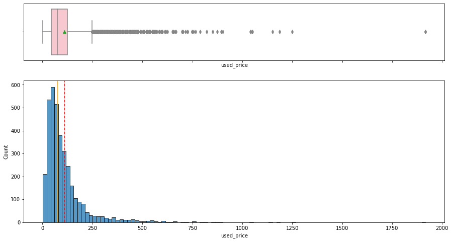

```python
histogram_boxplot(df, "used_price", bins=100)
```

**Observations**

- *used_price* is a right skewed distribution, which means that some used phones are on the expensive end.
- The mean for *used_phones* is greater than the median.

```python
def labeled_barplot(data, feature, perc=False, n=None):
    """
    Barplot with percentage at the top

    data: dataframe
    feature: dataframe column
    perc: whether to display percentages instead of count (default is False)
    n: displays the top n category levels (default is None, i.e., display all levels)
    """

    total = len(data[feature])
    count = data[feature].nunique()
    if n is None:
        plt.figure(figsize=(count + 1, 5))
    else:
        plt.figure(figsize=(n + 1, 5))

    plt.xticks(rotation=90, fontsize=15)
    ax = sns.countplot(
        data=data,
        x=feature,
        palette="Paired",
        order=data[feature].value_counts().index[:n].sort_values(),
    )

    for p in ax.patches:
        if perc == True:
            label = "{:.1f}%".format(
                100 * p.get_height() / total
            )
        else:
            label = p.get_height()

        x = p.get_x() + p.get_width() / 2
        y = p.get_height()

        ax.annotate(
            label,
            (x, y),
            ha="center",
            va="center",
            size=12,
            xytext=(0, 5),
            textcoords="offset points",
        )

    plt.show()
```

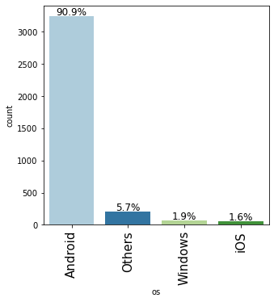

```python
plt.figure(figsize=(15,7))
labeled_barplot(df, 'os', perc=True)
```

**Observations**

- 90.9 percent of the market is dominated by Android devices, which is majority of the market.
- iOS bring in the least impact into the market with only 1.6 percent of the devices.

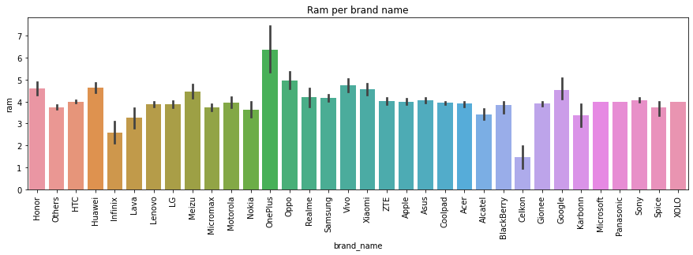

```python
plt.figure(figsize=(15,4))
sns.barplot(df['brand_name'], df['ram'])
plt.xticks(rotation=90)
plt.title('Ram per brand name')
```

**Observations**

- The OnePlus brand provides thw most Ram with 6GB compared to other devices while the Celkon provides the lowest Ram with just under 2GB.

```python
high_battery = df[df['battery']>4500]
```

```python
high_battery.shape
```

```
(346, 15)
```

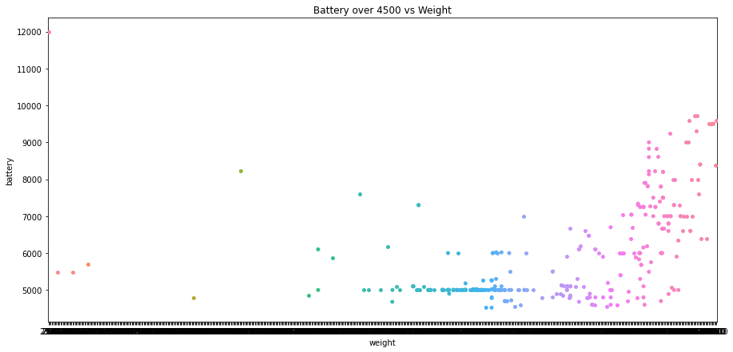

```python
plt.figure(figsize=(15,7))
sns.stripplot( df['weight'], high_battery['battery'], jitter=True);
plt.title('Battery over 4500 vs Weight')
```

```python
high_battery.describe()
```

|  | screen_size | main_camera_mp | selfie_camera_mp | int_memory | ram | battery | weight | release_year | days_used | new_price | used_price |
| --- | --- | --- | --- | --- | --- | --- | --- | --- | --- | --- | --- |
| count | 346.000000 | 346.000000 | 346.000000 | 346.000000 | 346.000000 | 346.000000 | 346.000000 | 346.000000 | 346.000000 | 346.000000 | 346.000000 |
| mean | 21.486618 | 9.001012 | 7.206069 | 59.144509 | 4.245665 | 5884.102601 | 330.718786 | 2017.112717 | 568.760116 | 307.461887 | 155.900954 |
| std | 5.169660 | 4.520376 | 6.254278 | 86.464113 | 1.466652 | 1327.656254 | 160.952677 | 2.455756 | 278.010401 | 200.482358 | 134.678164 |
| min | 10.160000 | 0.300000 | 0.300000 | 16.000000 | 1.000000 | 4520.000000 | 23.000000 | 2013.000000 | 92.000000 | 80.820000 | 33.090000 |
| 25% | 16.350000 | 8.000000 | 2.000000 | 16.000000 | 4.000000 | 5000.000000 | 198.000000 | 2015.000000 | 319.250000 | 180.142500 | 79.957500 |
| 50% | 20.960000 | 8.000000 | 5.000000 | 32.000000 | 4.000000 | 5100.000000 | 299.000000 | 2017.500000 | 581.500000 | 250.265000 | 111.460000 |
| 75% | 25.560000 | 13.000000 | 8.000000 | 64.000000 | 4.000000 | 6690.000000 | 467.000000 | 2019.000000 | 778.750000 | 351.097500 | 167.787500 |
| max | 46.360000 | 48.000000 | 32.000000 | 1024.000000 | 12.000000 | 12000.000000 | 950.000000 | 2020.000000 | 1089.000000 | 1200.850000 | 901.270000 |

**Observations**

- Data was split to include battery that was more than 4500 mAh.
- Seems from the graph as the battery mAh increses so does the weight, however this doesn't prove as much significance as some data points show that weight increases even with the battery mAh remaining the same.
- minimum battery mAh above was 4520 and maximum was 12000.
- minimum weight for battery mAh above 4500 was 23 grams and maximum weight was 950 grams.

```python
big_screens = df[df['screen_size']>6]
```

```python
brand_col=['brand_name']

#Printing number of count of each unique value in each column
for column in brand_col:
    print(big_screens[column].value_counts())
    print('-'*50)
```

```
Others        486
Samsung       342
Huawei        257
LG            204
Lenovo        172
ZTE           140
Xiaomi        134
Oppo          129
Asus          126
Honor         118
Alcatel       118
Vivo          117
Micromax      116
HTC           110
Motorola      110
Nokia          86
Sony           86
Meizu          62
Gionee         56
Apple          53
Acer           51
XOLO           49
Panasonic      47
Realme         41
Lava           36
Celkon         31
Karbonn        30
Spice          30
BlackBerry     22
Coolpad        22
Microsoft      22
OnePlus        22
Google         15
Infinix        10
Name: brand_name, dtype: int64
--------------------------------------------------
```

```python
big_screens.describe(include='all').T
```

|  | count | unique | top | freq | mean | std | min | 25% | 50% | 75% | max |
| --- | --- | --- | --- | --- | --- | --- | --- | --- | --- | --- | --- |
| brand_name | 3450 | 34 | Others | 486 | NaN | NaN | NaN | NaN | NaN | NaN | NaN |
| os | 3450 | 4 | Android | 3233 | NaN | NaN | NaN | NaN | NaN | NaN | NaN |
| screen_size | 3450.0 | NaN | NaN | NaN | 15.164391 | 4.858011 | 6.03 | 12.7 | 13.49 | 16.67 | 46.36 |
| 4g | 3450 | 2 | yes | 2342 | NaN | NaN | NaN | NaN | NaN | NaN | NaN |
| 5g | 3450 | 2 | no | 3298 | NaN | NaN | NaN | NaN | NaN | NaN | NaN |
| main_camera_mp | 3450.0 | NaN | NaN | NaN | 9.502061 | 4.619151 | 0.08 | 5.0 | 8.0 | 13.0 | 48.0 |
| selfie_camera_mp | 3450.0 | NaN | NaN | NaN | 6.652783 | 6.951971 | 0.3 | 2.0 | 5.0 | 8.0 | 32.0 |
| int_memory | 3450.0 | NaN | NaN | NaN | 54.394913 | 84.570963 | 0.005 | 16.0 | 32.0 | 64.0 | 1024.0 |
| ram | 3450.0 | NaN | NaN | NaN | 4.092554 | 1.321824 | 0.03 | 4.0 | 4.0 | 4.0 | 16.0 |
| battery | 3450.0 | NaN | NaN | NaN | 3136.200145 | 1326.865299 | 210.0 | 2100.0 | 3000.0 | 4000.0 | 12000.0 |
| weight | 3450.0 | NaN | NaN | NaN | 182.558971 | 89.820911 | 23.0 | 142.0 | 160.0 | 185.0 | 950.0 |
| release_year | 3450.0 | NaN | NaN | NaN | 2015.983188 | 2.292792 | 2013.0 | 2014.0 | 2016.0 | 2018.0 | 2020.0 |
| days_used | 3450.0 | NaN | NaN | NaN | 674.073333 | 249.452258 | 91.0 | 530.0 | 689.0 | 869.0 | 1094.0 |
| new_price | 3450.0 | NaN | NaN | NaN | 241.363428 | 197.102333 | 9.89 | 121.285 | 190.945 | 298.4625 | 2560.2 |
| used_price | 3450.0 | NaN | NaN | NaN | 112.006562 | 122.473111 | 3.06 | 47.8325 | 76.515 | 128.3975 | 1916.54 |

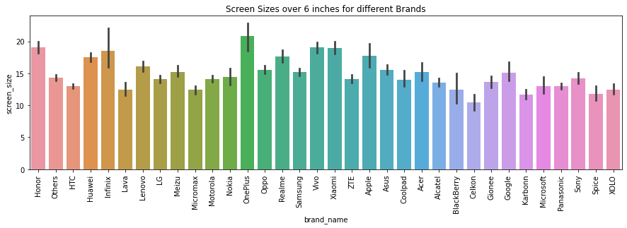

```python
plt.figure(figsize=(15,4))
sns.barplot(df['brand_name'], big_screens['screen_size'])
plt.xticks(rotation=90)
plt.title('Screen Sizes over 6 inches for different Brands')
```

**Observations**

```python
budget_phones_mp = df[df['selfie_camera_mp']>8]
```

```python
brand_col=['brand_name']

#Printing number of count of each unique value in each column
for column in brand_col:
    print(budget_phones_mp[column].value_counts())
    print('-'*50)
```

```
Huawei        91
Vivo          78
Oppo          75
Xiaomi        65
Samsung       60
Honor         43
Others        34
LG            32
Motorola      26
Meizu         24
ZTE           20
HTC           20
Realme        18
OnePlus       18
Lenovo        14
Sony          14
Nokia         10
Asus           6
Infinix        4
Gionee         4
Coolpad        3
Panasonic      2
Micromax       2
BlackBerry     2
Acer           1
Name: brand_name, dtype: int64
--------------------------------------------------
```

```python
budget_phones_mp.describe(include='all').T
```

|  | count | unique | top | freq | mean | std | min | 25% | 50% | 75% | max |
| --- | --- | --- | --- | --- | --- | --- | --- | --- | --- | --- | --- |
| brand_name | 666 | 25 | Huawei | 91 | NaN | NaN | NaN | NaN | NaN | NaN | NaN |
| os | 666 | 2 | Android | 653 | NaN | NaN | NaN | NaN | NaN | NaN | NaN |
| screen_size | 666.0 | NaN | NaN | NaN | 18.334054 | 4.592854 | 2.7 | 15.56 | 16.11 | 22.03 | 32.39 |
| 4g | 666 | 2 | yes | 655 | NaN | NaN | NaN | NaN | NaN | NaN | NaN |
| 5g | 666 | 2 | no | 535 | NaN | NaN | NaN | NaN | NaN | NaN | NaN |
| main_camera_mp | 666.0 | NaN | NaN | NaN | 11.386186 | 4.296768 | 0.3 | 8.0 | 12.0 | 13.0 | 48.0 |
| selfie_camera_mp | 666.0 | NaN | NaN | NaN | 18.67988 | 6.312393 | 9.0 | 16.0 | 16.0 | 20.0 | 32.0 |
| int_memory | 666.0 | NaN | NaN | NaN | 108.24024 | 83.032973 | 4.0 | 64.0 | 128.0 | 128.0 | 1024.0 |
| ram | 666.0 | NaN | NaN | NaN | 5.266231 | 2.088821 | 0.03 | 4.0 | 4.0 | 6.0 | 16.0 |
| battery | 666.0 | NaN | NaN | NaN | 3828.558559 | 776.01267 | 230.0 | 3400.0 | 4000.0 | 4200.0 | 6000.0 |
| weight | 666.0 | NaN | NaN | NaN | 180.389715 | 28.710823 | 25.0 | 165.55 | 181.0 | 196.375 | 300.0 |
| release_year | 666.0 | NaN | NaN | NaN | 2018.630631 | 1.234306 | 2013.0 | 2018.0 | 2019.0 | 2019.0 | 2020.0 |
| days_used | 666.0 | NaN | NaN | NaN | 424.1997 | 206.415809 | 91.0 | 264.0 | 385.5 | 545.25 | 1091.0 |
| new_price | 666.0 | NaN | NaN | NaN | 387.318341 | 291.620694 | 99.7 | 218.9225 | 299.34 | 459.87 | 2560.2 |
| used_price | 666.0 | NaN | NaN | NaN | 228.294144 | 195.125751 | 35.74 | 118.4 | 165.02 | 268.5025 | 1916.54 |

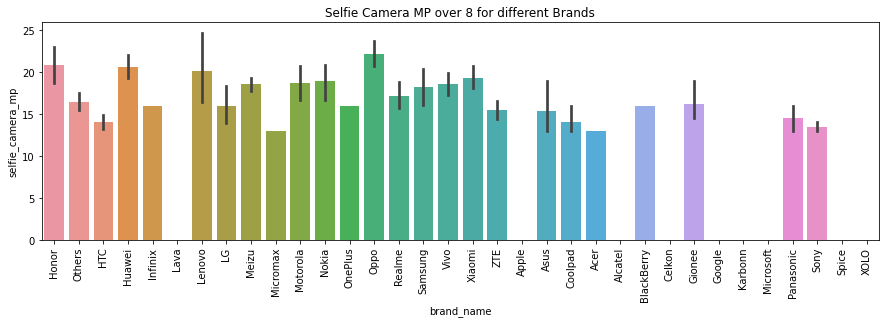

```python
plt.figure(figsize=(15,4))
sns.barplot(df['brand_name'], budget_phones_mp['selfie_camera_mp'])
plt.xticks(rotation=90)
plt.title('Selfie Camera MP over 8 for different Brands')
```

**Observations**

- Only 25 out of the 34 brands have *selfire_camera_mp* greater than 8 megapixels.
- Huawei brand has the largest quantity of phones over 8 mega pixels for the selfie camera and OnePlus has the largest screens however the "Other" brand names seem to have the largest quantity of phones over 6 inches.
- The original data had 3571 total phones, out of the total only 666 are over 8 megapixels for the selfie camera, which is only **18.65 percent** of the phones are over 8 megapixels for the selfie camera.
- Android OS has the largest amount of phones with over 8 megapixels selfie cameras.

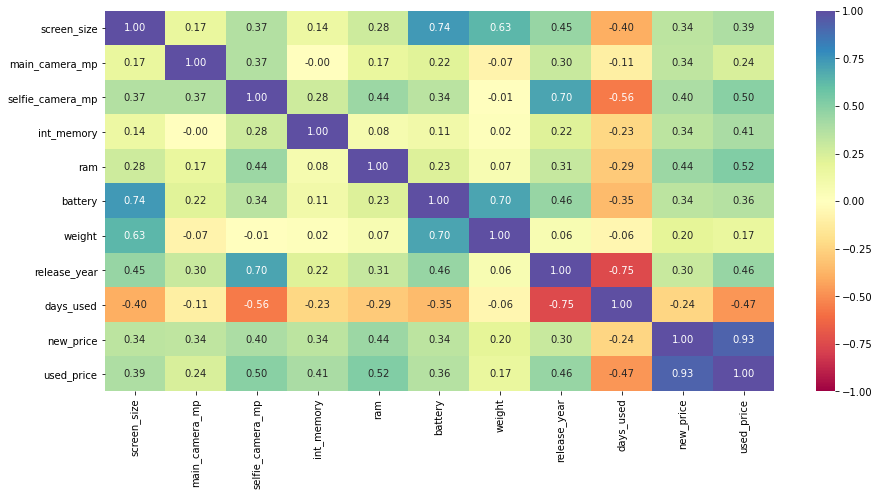

```python
numeric_columns = df.select_dtypes(include=np.number).columns.tolist()

# correlation heatmap
plt.figure(figsize=(15, 7))
sns.heatmap(
    df[numeric_columns].corr(),
    annot=True,
    vmin=-1,
    vmax=1,
    fmt=".2f",
    cmap="Spectral",
)
plt.show()
```

**Observations**

- *used_price* is negatively correlated with *days_used* , which means that as the days used for a phone increases the used price decreases.
- *used_price* is highly positively correlated with *new_price*, which means as the new price value increases so does the used price.
- Along with that *realease_year*, *ram* and *selfie_camera_mp* are also positively correlated, which means that as the release year is newer, the ram is greater, and the megapixels for the selfie camer are more than so is the used price of the phones.

**Let's look at the graphs of a few variables that are highly correlated with *used_price*.**

*used_price* vs *days_used* vs *os*

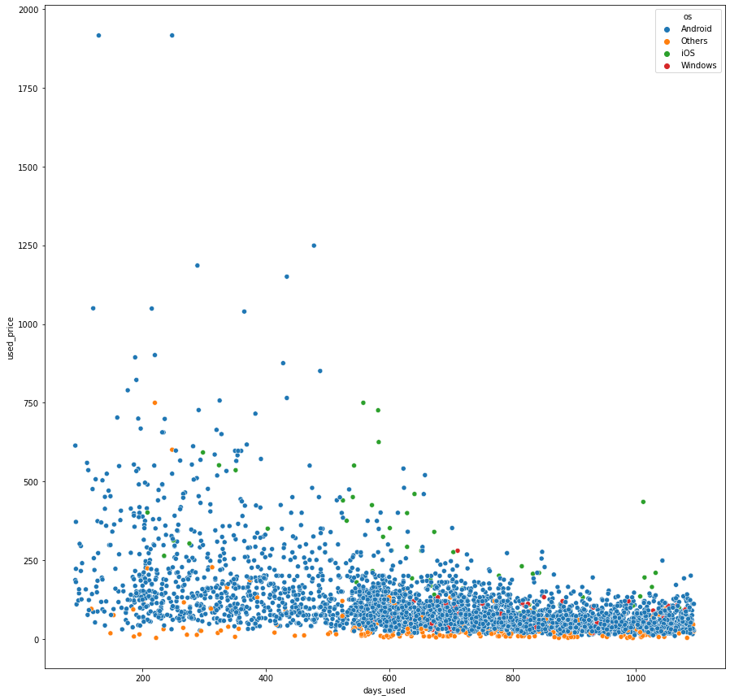

```python
plt.figure(figsize=(15, 15))
sns.scatterplot(y="used_price", x="days_used", hue='os', data=df)
plt.show()
```

**Observations**

- iOS devices tend to hold their value even if they get used longer.
- After roughly 600 days Android phones loss there value.

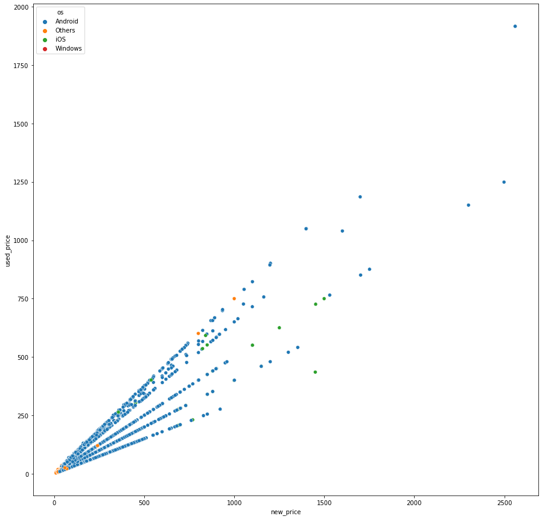

```python
plt.figure(figsize=(15, 15))
sns.scatterplot(y="used_price", x="new_price", hue='os', data=df)
plt.show()
```

**Observations**

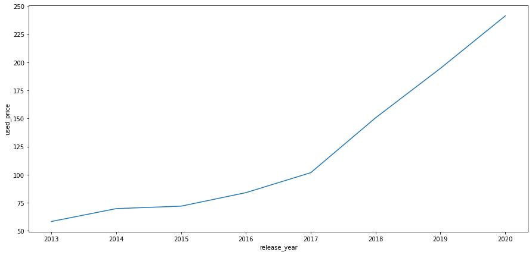

```python
plt.figure(figsize=(15, 7))
sns.lineplot(x="release_year", y="used_price", data=df, ci=None)
plt.show()
```

**Observations**

- *used_price* value increase as the *release_year* is newer.

## Data Preprocessing

- Missing value treatment
- Feature engineering (if needed)
- Outlier detection and treatment (if needed)
- Preparing data for modeling
- Any other preprocessing steps (if needed)

```python
df.isnull().sum() #check the missing values
```

```
brand_name            0
os                    0
screen_size           0
4g                    0
5g                    0
main_camera_mp      180
selfie_camera_mp      2
int_memory           10
ram                  10
battery               6
weight                7
release_year          0
days_used             0
new_price             0
used_price            0
dtype: int64
```

```python
medianFiller = lambda x: x.fillna(x.median())
numeric_columns = df.select_dtypes(include=np.number).columns.tolist()
df[numeric_columns] = df[numeric_columns].apply(medianFiller, axis=0)
```

```python
# checking the number of missing values
df.isnull().sum()
```

```
brand_name          0
os                  0
screen_size         0
4g                  0
5g                  0
main_camera_mp      0
selfie_camera_mp    0
int_memory          0
ram                 0
battery             0
weight              0
release_year        0
days_used           0
new_price           0
used_price          0
dtype: int64
```

**Observations**

- The target variable had 0 missing values.
- The *main_camera_mp* column had the most missing values.
- For the predictor variables missing values were replaced with its median in each column.
- All the missing values have been treated

```python
df.describe(include='all').T
```

|  | count | unique | top | freq | mean | std | min | 25% | 50% | 75% | max |
| --- | --- | --- | --- | --- | --- | --- | --- | --- | --- | --- | --- |
| brand_name | 3571 | 34 | Others | 509 | NaN | NaN | NaN | NaN | NaN | NaN | NaN |
| os | 3571 | 4 | Android | 3246 | NaN | NaN | NaN | NaN | NaN | NaN | NaN |
| screen_size | 3571.0 | NaN | NaN | NaN | 14.803892 | 5.153092 | 2.7 | 12.7 | 13.49 | 16.51 | 46.36 |
| 4g | 3571 | 2 | yes | 2359 | NaN | NaN | NaN | NaN | NaN | NaN | NaN |
| 5g | 3571 | 2 | no | 3419 | NaN | NaN | NaN | NaN | NaN | NaN | NaN |
| main_camera_mp | 3571.0 | NaN | NaN | NaN | 9.329863 | 4.705341 | 0.08 | 5.0 | 8.0 | 13.0 | 48.0 |
| selfie_camera_mp | 3571.0 | NaN | NaN | NaN | 6.546486 | 6.877529 | 0.3 | 2.0 | 5.0 | 8.0 | 32.0 |
| int_memory | 3571.0 | NaN | NaN | NaN | 54.469509 | 84.585924 | 0.005 | 16.0 | 32.0 | 64.0 | 1024.0 |
| ram | 3571.0 | NaN | NaN | NaN | 4.056802 | 1.389897 | 0.03 | 4.0 | 4.0 | 4.0 | 16.0 |
| battery | 3571.0 | NaN | NaN | NaN | 3067.112714 | 1363.062572 | 80.0 | 2100.0 | 3000.0 | 4000.0 | 12000.0 |
| weight | 3571.0 | NaN | NaN | NaN | 179.384248 | 90.196828 | 23.0 | 140.0 | 159.0 | 184.0 | 950.0 |
| release_year | 3571.0 | NaN | NaN | NaN | 2015.964996 | 2.291784 | 2013.0 | 2014.0 | 2016.0 | 2018.0 | 2020.0 |
| days_used | 3571.0 | NaN | NaN | NaN | 675.391487 | 248.640972 | 91.0 | 536.0 | 690.0 | 872.0 | 1094.0 |
| new_price | 3571.0 | NaN | NaN | NaN | 237.389037 | 197.545581 | 9.13 | 120.13 | 189.8 | 291.935 | 2560.2 |
| used_price | 3571.0 | NaN | NaN | NaN | 109.880277 | 121.501226 | 2.51 | 45.205 | 75.53 | 126.0 | 1916.54 |

**Observations**

- The *4g* and *5g* column both have 2 unique values - "*yes*" and "*no*"
- The *brand_name* column has 34 unique values
- *release_year* ranges from 2013 to 2020.
- Average *used_price* is about 109.88 euros.

```python
#Making a list of all categorical variables
cat_col=['brand_name', '4g', '5g']

#Printing number of count of each unique value in each column
for column in cat_col:
    print(df[column].value_counts())
    print('-'*50)
```

```
Others        509
Samsung       364
Huawei        264
LG            212
Lenovo        172
ZTE           141
Xiaomi        134
Oppo          129
Asus          126
Alcatel       125
Nokia         121
Micromax      120
Honor         118
Vivo          117
Motorola      110
HTC           110
Sony           88
Meizu          62
Apple          59
Gionee         56
Acer           51
XOLO           49
Panasonic      47
Realme         41
Celkon         37
Lava           36
Karbonn        30
Spice          30
BlackBerry     22
Coolpad        22
Microsoft      22
OnePlus        22
Google         15
Infinix        10
Name: brand_name, dtype: int64
--------------------------------------------------
yes    2359
no     1212
Name: 4g, dtype: int64
--------------------------------------------------
no     3419
yes     152
Name: 5g, dtype: int64
--------------------------------------------------
```

**Observations**

- More phones use 4g compared to 5g since 5g is still a farely new technological enhacement.
- Other brand names dominate the market compared to a specific branded name.

**converting object type colums to category type**

```python
df["brand_name"] = df["brand_name"].astype("category")
df["os"] = df["os"].astype("category")
df["4g"] = df["4g"].astype("category")
df["5g"] = df["5g"].astype("category")
```

```python
df.info()
```

```
<class 'pandas.core.frame.DataFrame'>
Int64Index: 3571 entries, 0 to 3570
Data columns (total 15 columns):
 #   Column            Non-Null Count  Dtype
---  ------            --------------  -----
 0   brand_name        3571 non-null   category
 1   os                3571 non-null   category
 2   screen_size       3571 non-null   float64
 3   4g                3571 non-null   category
 4   5g                3571 non-null   category
 5   main_camera_mp    3571 non-null   float64
 6   selfie_camera_mp  3571 non-null   float64
 7   int_memory        3571 non-null   float64
 8   ram               3571 non-null   float64
 9   battery           3571 non-null   float64
 10  weight            3571 non-null   float64
 11  release_year      3571 non-null   int64
 12  days_used         3571 non-null   int64
 13  new_price         3571 non-null   float64
 14  used_price        3571 non-null   float64
dtypes: category(4), float64(9), int64(2)
memory usage: 479.5 KB
```

### Outlier Detection

- Let's look at outliers in every numerical column

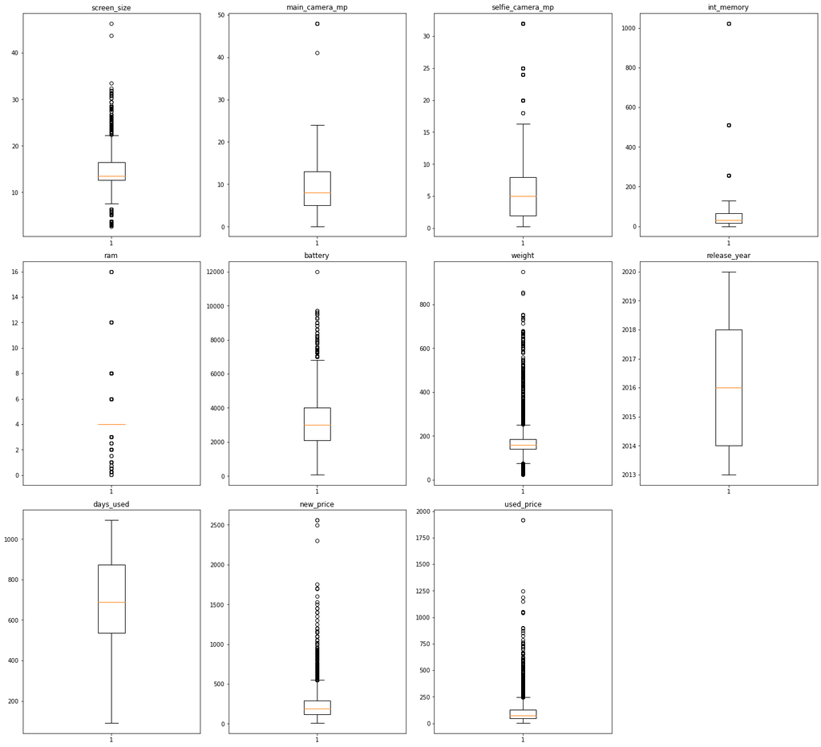

```python
# let's plot the boxplots of all columns to check for outliers
plt.figure(figsize=(20, 30))

for i, variable in enumerate(numeric_columns):
    plt.subplot(5, 4, i + 1)
    plt.boxplot(df[variable], whis=1.5)
    plt.tight_layout()
    plt.title(variable)

plt.show()
```

**Observations**

### Outlier Treatment

- Let's treat outliers in the data by flooring and capping.

```python
def treat_outliers(df, col):
    """
    treats outliers in a variable
    col: str, name of the numerical variable
    df: dataframe
    col: name of the column
    """
    Q1 = df[col].quantile(0.25)  # 25th quantile
    Q3 = df[col].quantile(0.75)  # 75th quantile
    IQR = Q3 - Q1
    Lower_Whisker = Q1 - 1.5 * IQR
    Upper_Whisker = Q3 + 1.5 * IQR

    # all the values smaller than Lower_Whisker will be assigned the value of Lower_Whisker
    # all the values greater than Upper_Whisker will be assigned the value of Upper_Whisker
    df[col] = np.clip(df[col], Lower_Whisker, Upper_Whisker)

    return df


def treat_outliers_all(df, col_list):
    """
    treat outlier in all numerical variables
    col_list: list of numerical variables
    df: data frame
    """
    for c in col_list:
        df = treat_outliers(df, c)

    return df
```

```python
# treating the outliers
numerical_col = df.select_dtypes(include=np.number).columns.tolist()
df = treat_outliers_all(df, numerical_col)
```

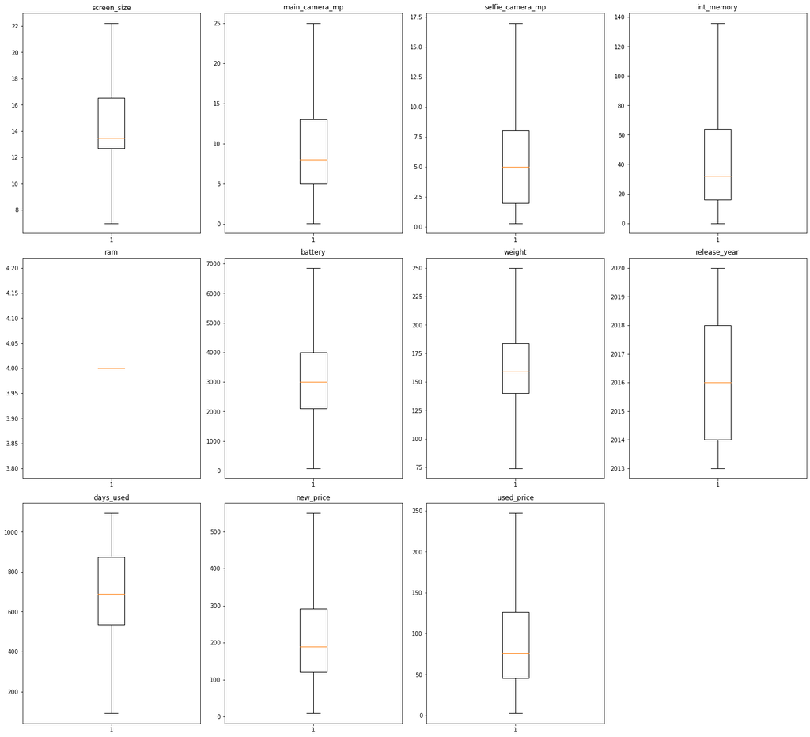

```python
# let's look at the boxplots to see if the outliers have been treated or not
plt.figure(figsize=(20, 30))

for i, variable in enumerate(numeric_columns):
    plt.subplot(5, 4, i + 1)
    plt.boxplot(df[variable], whis=1.5)
    plt.tight_layout()
    plt.title(variable)

plt.show()
```

## Building a Linear Regression model

1. Predict the price of a used phone.
2. Before building a model, categorical features need to be encoded.
3. Split the data into train and test to be able to evaluate the model that will be built on the train data.
4. Build a Linear Regression model using the train data and then check it's performance.

```python
pd.get_dummies(df['5g'], drop_first=True)
```

|  | yes |
| --- | --- |
| 0 | 0 |
| 1 | 1 |
| 2 | 1 |
| 3 | 1 |
| 4 | 0 |
| ... | ... |
| 3566 | 0 |
| 3567 | 0 |
| 3568 | 0 |
| 3569 | 0 |
| 3570 | 0 |

3571 rows × 1 columns

```python
pd.get_dummies(df['4g'], drop_first=True)
```

|  | yes |
| --- | --- |
| 0 | 1 |
| 1 | 1 |
| 2 | 1 |
| 3 | 1 |
| 4 | 1 |
| ... | ... |
| 3566 | 1 |
| 3567 | 1 |
| 3568 | 1 |
| 3569 | 1 |
| 3570 | 1 |

3571 rows × 1 columns

```python
# defining X and y variables
X = df.drop(["used_price", "os"], axis=1)
y = df["used_price"]

print(X.head())
print(y.head())
```

```
  brand_name  screen_size   4g   5g  main_camera_mp  selfie_camera_mp  \
0      Honor       22.225  yes   no            13.0               5.0
1      Honor       22.225  yes  yes            13.0              16.0
2      Honor       22.225  yes  yes            13.0               8.0
3      Honor       22.225  yes  yes            13.0               8.0
4      Honor       15.720  yes   no            13.0               8.0

   int_memory  ram  battery  weight  release_year  days_used  new_price
0        64.0  4.0   3020.0   146.0          2020        127     111.62
1       128.0  4.0   4300.0   213.0          2020        325     249.39
2       128.0  4.0   4200.0   213.0          2020        162     359.47
3        64.0  4.0   6850.0   250.0          2020        345     278.93
4        64.0  4.0   5000.0   185.0          2020        293     140.87
0     86.9600
1    161.4900
2    247.1925
3    180.2300
4    103.8000
Name: used_price, dtype: float64
```

```python
X.head()
```

|  | brand_name | screen_size | 4g | 5g | main_camera_mp | selfie_camera_mp | int_memory | ram | battery | weight | release_year | days_used | new_price |
| --- | --- | --- | --- | --- | --- | --- | --- | --- | --- | --- | --- | --- | --- |
| 0 | Honor | 22.225 | yes | no | 13.0 | 5.0 | 64.0 | 4.0 | 3020.0 | 146.0 | 2020 | 127 | 111.62 |
| 1 | Honor | 22.225 | yes | yes | 13.0 | 16.0 | 128.0 | 4.0 | 4300.0 | 213.0 | 2020 | 325 | 249.39 |
| 2 | Honor | 22.225 | yes | yes | 13.0 | 8.0 | 128.0 | 4.0 | 4200.0 | 213.0 | 2020 | 162 | 359.47 |
| 3 | Honor | 22.225 | yes | yes | 13.0 | 8.0 | 64.0 | 4.0 | 6850.0 | 250.0 | 2020 | 345 | 278.93 |
| 4 | Honor | 15.720 | yes | no | 13.0 | 8.0 | 64.0 | 4.0 | 5000.0 | 185.0 | 2020 | 293 | 140.87 |

```python
y.head()
```

```
0     86.9600
1    161.4900
2    247.1925
3    180.2300
4    103.8000
Name: used_price, dtype: float64
```

```python
X = pd.get_dummies(
    X,
    columns=X.select_dtypes(include=["object", "category"]).columns.tolist(),
    drop_first=True,
)
X.head()
```

|  | screen_size | main_camera_mp | selfie_camera_mp | int_memory | ram | battery | weight | release_year | days_used | new_price | ... | brand_name_Realme | brand_name_Samsung | brand_name_Sony | brand_name_Spice | brand_name_Vivo | brand_name_XOLO | brand_name_Xiaomi | brand_name_ZTE | 4g_yes | 5g_yes |
| --- | --- | --- | --- | --- | --- | --- | --- | --- | --- | --- | --- | --- | --- | --- | --- | --- | --- | --- | --- | --- | --- |
| 0 | 22.225 | 13.0 | 5.0 | 64.0 | 4.0 | 3020.0 | 146.0 | 2020 | 127 | 111.62 | ... | 0 | 0 | 0 | 0 | 0 | 0 | 0 | 0 | 1 | 0 |
| 1 | 22.225 | 13.0 | 16.0 | 128.0 | 4.0 | 4300.0 | 213.0 | 2020 | 325 | 249.39 | ... | 0 | 0 | 0 | 0 | 0 | 0 | 0 | 0 | 1 | 1 |
| 2 | 22.225 | 13.0 | 8.0 | 128.0 | 4.0 | 4200.0 | 213.0 | 2020 | 162 | 359.47 | ... | 0 | 0 | 0 | 0 | 0 | 0 | 0 | 0 | 1 | 1 |
| 3 | 22.225 | 13.0 | 8.0 | 64.0 | 4.0 | 6850.0 | 250.0 | 2020 | 345 | 278.93 | ... | 0 | 0 | 0 | 0 | 0 | 0 | 0 | 0 | 1 | 1 |
| 4 | 15.720 | 13.0 | 8.0 | 64.0 | 4.0 | 5000.0 | 185.0 | 2020 | 293 | 140.87 | ... | 0 | 0 | 0 | 0 | 0 | 0 | 0 | 0 | 1 | 0 |

5 rows × 45 columns

```python
# splitting the data in 70:30 ratio for train to test data

x_train, x_test, y_train, y_test = train_test_split(
    X, y, test_size=0.3, random_state=42
)
```

```python
print("Number of rows in train data =", x_train.shape[0])
print("Number of rows in test data =", x_test.shape[0])
```

```
Number of rows in train data = 2499
Number of rows in test data = 1072
```

```python
from sklearn.linear_model import LinearRegression
```

```python
linearregression = LinearRegression()
linearregression.fit(x_train, y_train)
```

```
LinearRegression()
```

**Let's check the coefficients and intercept of the model.**

```python
coef_df = pd.DataFrame(
    np.append(linearregression.coef_, linearregression.intercept_),
    index=x_train.columns.tolist() + ["Intercept"],
    columns=["Coefficients"],
)

coef_df
```

|  | Coefficients |
| --- | --- |
| screen_size | 2.858870e-01 |
| main_camera_mp | -2.311402e-01 |
| selfie_camera_mp | 8.146790e-01 |
| int_memory | 8.458149e-02 |
| ram | 1.137573e-11 |
| battery | 1.334163e-04 |
| weight | -1.007949e-02 |
| release_year | -3.006716e-01 |
| days_used | -8.447698e-02 |
| new_price | 3.847816e-01 |
| brand_name_Alcatel | -1.193103e-01 |
| brand_name_Apple | 7.822576e+00 |
| brand_name_Asus | 2.595915e-01 |
| brand_name_BlackBerry | 4.326838e+00 |
| brand_name_Celkon | -1.821052e+00 |
| brand_name_Coolpad | 6.449315e+00 |
| brand_name_Gionee | -5.382461e+00 |
| brand_name_Google | 1.203067e+01 |
| brand_name_HTC | -6.881854e-01 |
| brand_name_Honor | 1.648339e+00 |
| brand_name_Huawei | 6.018954e-01 |
| brand_name_Infinix | -1.500494e+01 |
| brand_name_Karbonn | -1.157472e+00 |
| brand_name_LG | 1.521912e+00 |
| brand_name_Lava | -1.067047e+00 |
| brand_name_Lenovo | -1.916954e+00 |
| brand_name_Meizu | -8.657582e-01 |
| brand_name_Micromax | 1.009366e+00 |
| brand_name_Microsoft | -8.564902e-01 |
| brand_name_Motorola | -8.437146e-01 |
| brand_name_Nokia | -8.489033e+00 |
| brand_name_OnePlus | -1.718589e+01 |
| brand_name_Oppo | -2.677100e+00 |
| brand_name_Others | 1.896825e-01 |
| brand_name_Panasonic | 1.268004e+00 |
| brand_name_Realme | -2.797048e+00 |
| brand_name_Samsung | 6.478524e-02 |
| brand_name_Sony | 6.195154e-01 |
| brand_name_Spice | 2.030718e+00 |
| brand_name_Vivo | 5.783080e-01 |
| brand_name_XOLO | 2.984728e+00 |
| brand_name_Xiaomi | -1.689371e+00 |
| brand_name_ZTE | -6.965124e-01 |
| 4g_yes | -2.566262e+00 |
| 5g_yes | 2.257784e+00 |
| Intercept | 6.659278e+02 |

**Let's check the performance of the model using different metrics.**

- We will be using metric functions defined in sklearn for RMSE, MAE, and $R^2$.
- We will define a function to calculate MAPE and adjusted $R^2$.
  - The mean absolute percentage error (MAPE) measures the accuracy of predictions as a percentage, and can be calculated as the average absolute percent error for each predicted value minus actual values divided by actual values. It works best if there are no extreme values in the data and none of the actual values are 0.
- We will create a function which will print out all the above metrics in one go.

```python
# function to compute adjusted R-squared
def adj_r2_score(predictors, targets, predictions):
    r2 = r2_score(targets, predictions)
    n = predictors.shape[0]
    k = predictors.shape[1]
    return 1 - ((1 - r2) * (n - 1) / (n - k - 1))


# function to compute MAPE
def mape_score(targets, predictions):
    return np.mean(np.abs(targets - predictions) / targets) * 100


# function to compute different metrics to check performance of a regression model
def model_performance_regression(model, predictors, target):
    """
    Function to compute different metrics to check regression model performance

    model: regressor
    predictors: independent variables
    target: dependent variable
    """

    # predicting using the independent variables
    pred = model.predict(predictors)

    r2 = r2_score(target, pred)  # to compute R-squared
    adjr2 = adj_r2_score(predictors, target, pred)  # to compute adjusted R-squared
    rmse = np.sqrt(mean_squared_error(target, pred))  # to compute RMSE
    mae = mean_absolute_error(target, pred)  # to compute MAE
    mape = mape_score(target, pred)  # to compute MAPE

    # creating a dataframe of metrics
    df_perf = pd.DataFrame(
        {
            "RMSE": rmse,
            "MAE": mae,
            "R-squared": r2,
            "Adj. R-squared": adjr2,
            "MAPE": mape,
        },
        index=[0],
    )

    return df_perf
```

```python
# checking model performance on train set (seen 70% data)
print("Training Performance\n")
linearregression_train_perf = model_performance_regression(
    linearregression, x_train, y_train
)
linearregression_train_perf
```

```
Training Performance
```

|  | RMSE | MAE | R-squared | Adj. R-squared | MAPE |
| --- | --- | --- | --- | --- | --- |
| 0 | 13.988714 | 10.251215 | 0.954954 | 0.954127 | 18.48133 |

```python
# checking model performance on test set (seen 30% data)
print("Test Performance\n")
linearregression_test_perf = model_performance_regression(
    linearregression, x_test, y_test
)
linearregression_test_perf
```

```
Test Performance
```

|  | RMSE | MAE | R-squared | Adj. R-squared | MAPE |
| --- | --- | --- | --- | --- | --- |
| 0 | 13.730895 | 10.146914 | 0.957532 | 0.955669 | 16.308935 |

**Observations**

- The training $R^2$ is 95.5%, indicating that the model explains 95.5% of the variation in the train data. So, the model is not underfitting.
- MAE and RMSE on the train and test sets are comparable, which shows that the model is not overfitting.
- MAE indicates that our current model is able to predict used price within a mean error of 10.15 euros on the test data.
- MAPE on the test set suggests we can predict within 16.31% of the used price.

## Linear Regression using statsmodels

```python
# unlike sklearn, statsmodels does not add a constant to the data on its own
# we have to add the constant manually
x_train1 = sm.add_constant(x_train)
# adding constant to the test data
x_test1 = sm.add_constant(x_test)

olsmod0 = sm.OLS(y_train, x_train1).fit()
print(olsmod0.summary())
```

```
                            OLS Regression Results
==============================================================================
Dep. Variable:             used_price   R-squared:                       0.955
Model:                            OLS   Adj. R-squared:                  0.954
Method:                 Least Squares   F-statistic:                     1182.
Date:                Sun, 24 Oct 2021   Prob (F-statistic):               0.00
Time:                        08:30:46   Log-Likelihood:                -10139.
No. Observations:                2499   AIC:                         2.037e+04
Df Residuals:                    2454   BIC:                         2.063e+04
Df Model:                          44
Covariance Type:            nonrobust
=========================================================================================
                            coef    std err          t      P>|t|      [0.025      0.975]
-----------------------------------------------------------------------------------------
screen_size               0.2859      0.124      2.304      0.021       0.043       0.529
main_camera_mp           -0.2311      0.091     -2.541      0.011      -0.410      -0.053
selfie_camera_mp          0.8147      0.104      7.796      0.000       0.610       1.020
int_memory                0.0846      0.011      7.889      0.000       0.064       0.106
ram                     166.4819    137.935      1.207      0.228    -103.999     436.963
battery                   0.0001      0.000      0.308      0.758      -0.001       0.001
weight                   -0.0101      0.012     -0.813      0.416      -0.034       0.014
release_year             -0.3007      0.274     -1.099      0.272      -0.837       0.236
days_used                -0.0845      0.002    -46.282      0.000      -0.088      -0.081
new_price                 0.3848      0.003    111.742      0.000       0.378       0.392
brand_name_Alcatel       -0.1193      2.956     -0.040      0.968      -5.915       5.676
brand_name_Apple          7.8226      3.500      2.235      0.026       0.959      14.686
brand_name_Asus           0.2596      2.944      0.088      0.930      -5.513       6.032
brand_name_BlackBerry     4.3268      4.573      0.946      0.344      -4.641      13.295
brand_name_Celkon        -1.8211      3.843     -0.474      0.636      -9.357       5.715
brand_name_Coolpad        6.4493      4.575      1.410      0.159      -2.521      15.420
brand_name_Gionee        -5.3825      3.405     -1.581      0.114     -12.059       1.294
brand_name_Google        12.0307      4.865      2.473      0.013       2.491      21.570
brand_name_HTC           -0.6882      3.002     -0.229      0.819      -6.576       5.199
brand_name_Honor          1.6483      3.021      0.546      0.585      -4.275       7.572
brand_name_Huawei         0.6019      2.762      0.218      0.828      -4.814       6.018
brand_name_Infinix      -15.0049      6.374     -2.354      0.019     -27.504      -2.506
brand_name_Karbonn       -1.1575      3.878     -0.298      0.765      -8.761       6.446
brand_name_LG             1.5219      2.778      0.548      0.584      -3.926       6.970
brand_name_Lava          -1.0670      3.709     -0.288      0.774      -8.340       6.206
brand_name_Lenovo        -1.9170      2.849     -0.673      0.501      -7.504       3.670
```

[output cut: 15 more lines]

```
brand_name_Xiaomi        -1.6894      2.953     -0.572      0.567      -7.479       4.101
brand_name_ZTE           -0.6965      2.978     -0.234      0.815      -6.536       5.143
4g_yes                   -2.5663      0.908     -2.827      0.005      -4.346      -0.786
5g_yes                    2.2578      1.724      1.309      0.191      -1.124       5.639
==============================================================================
Omnibus:                      284.009   Durbin-Watson:                   1.982
Prob(Omnibus):                  0.000   Jarque-Bera (JB):              636.420
Skew:                           0.680   Prob(JB):                    6.36e-139
Kurtosis:                       5.064   Cond. No.                     1.88e+06
==============================================================================

Notes:
[1] Standard Errors assume that the covariance matrix of the errors is correctly specified.
[2] The condition number is large, 1.88e+06. This might indicate that there are
strong multicollinearity or other numerical problems.
```

- Negative values of the coefficient show that *used_prices* decreases with the increase of corresponding attribute value.
- Positive values of the coefficient show that *used_prices* increases with the increase of corresponding attribute value. m
- p-value of a variable indicates if the variable is significant or not. If we consider the significance level to be 0.05 (5%), then any variable with a p-value less than 0.05 would be considered significant.
- But these variables might contain multicollinearity, which will affect the p-values.
- So, we need to deal with multicollinearity and check the other assumptions of linear regression first, and then look at the p-values.

## Checking Linear Regression Assumptions

- In order to make statistical inferences from a linear regression model, it is important to ensure that the assumptions of linear regression are satisfied.

We will be checking the following Linear Regression assumptions:

1. **No Multicollinearity**
2. **Linearity of variables**
3. **Independence of error terms**
4. **Normality of error terms**
5. **No Heteroscedasticity**

### TEST FOR MULTICOLLINEARITY

- Multicollinearity occurs when predictor variables in a regression model are correlated. This correlation is a problem because predictor variables should be independent. If the correlation between variables is high, it can cause problems when we fit the model and interpret the results. When we have multicollinearity in the linear model, the coefficients that the model suggests are unreliable.
- There are different ways of detecting (or testing) multicollinearity. One such way is by using the Variance Inflation Factor, or VIF.
- **Variance Inflation Factor (VIF)**: Variance inflation factors measure the inflation in the variances of the regression parameter estimates due to collinearities that exist among the predictors. It is a measure of how much the variance of the estimated regression coefficient $\beta_k$ is "inflated" by the existence of correlation among the predictor variables in the model.
  - If VIF is 1, then there is no correlation among the $k$th predictor and the remaining predictor variables, and hence, the variance of $\beta_k$ is not inflated at all.
- **General Rule of thumb**:
  - If VIF is between 1 and 5, then there is low multicollinearity.
  - If VIF is between 5 and 10, we say there is moderate multicollinearity.
  - If VIF is exceeding 10, it shows signs of high multicollinearity.

```python
from statsmodels.stats.outliers_influence import variance_inflation_factor

# we will define a function to check VIF
def checking_vif(predictors):
    vif = pd.DataFrame()
    vif["feature"] = predictors.columns

    # calculating VIF for each feature
    vif["VIF"] = [
        variance_inflation_factor(predictors.values, i)
        for i in range(len(predictors.columns))
    ]
    return vif
```

```python
checking_vif(x_train1)
```

|  | feature | VIF |
| --- | --- | --- |
| 0 | screen_size | 3.350630e+00 |
| 1 | main_camera_mp | 2.176040e+00 |
| 2 | selfie_camera_mp | 3.837571e+00 |
| 3 | int_memory | 2.174724e+00 |
| 4 | ram | 3.817585e+06 |
| 5 | battery | 3.711431e+00 |
| 6 | weight | 3.191612e+00 |
| 7 | release_year | 4.961670e+00 |
| 8 | days_used | 2.626499e+00 |
| 9 | new_price | 2.707538e+00 |
| 10 | brand_name_Alcatel | 3.476730e+00 |
| 11 | brand_name_Apple | 2.360159e+00 |
| 12 | brand_name_Asus | 3.610720e+00 |
| 13 | brand_name_BlackBerry | 1.461198e+00 |
| 14 | brand_name_Celkon | 1.979292e+00 |
| 15 | brand_name_Coolpad | 1.462081e+00 |
| 16 | brand_name_Gionee | 2.177256e+00 |
| 17 | brand_name_Google | 1.418390e+00 |
| 18 | brand_name_HTC | 3.418221e+00 |
| 19 | brand_name_Honor | 3.717442e+00 |
| 20 | brand_name_Huawei | 6.460464e+00 |
| 21 | brand_name_Infinix | 1.220359e+00 |
| 22 | brand_name_Karbonn | 1.719520e+00 |
| 23 | brand_name_LG | 5.597086e+00 |
| 24 | brand_name_Lava | 1.843567e+00 |
| 25 | brand_name_Lenovo | 4.395393e+00 |
| 26 | brand_name_Meizu | 2.401580e+00 |
| 27 | brand_name_Micromax | 3.539742e+00 |
| 28 | brand_name_Microsoft | 1.532342e+00 |
| 29 | brand_name_Motorola | 3.827072e+00 |
| 30 | brand_name_Nokia | 3.770984e+00 |
| 31 | brand_name_OnePlus | 1.622572e+00 |
| 32 | brand_name_Oppo | 4.077598e+00 |
| 33 | brand_name_Others | 1.053508e+01 |
| 34 | brand_name_Panasonic | 2.102430e+00 |
| 35 | brand_name_Realme | 1.853939e+00 |
| 36 | brand_name_Samsung | 8.421245e+00 |
| 37 | brand_name_Sony | 2.889257e+00 |
| 38 | brand_name_Spice | 1.626831e+00 |
| 39 | brand_name_Vivo | 3.491259e+00 |
| 40 | brand_name_XOLO | 2.108098e+00 |
| 41 | brand_name_Xiaomi | 4.159576e+00 |
| 42 | brand_name_ZTE | 3.571012e+00 |
| 43 | 4g_yes | 2.336367e+00 |
| 44 | 5g_yes | 1.473737e+00 |

### Removing Multicollinearity

To remove multicollinearity

1. Drop every column one by one that has a VIF score greater than 5.
2. Look at the adjusted R-squared and RMSE of all these models.
3. Drop the variable that makes the least change in adjusted R-squared.
4. Check the VIF scores again.
5. Continue till you get all VIF scores under 5.

Let's define a function that will help us do this.

```python
def treating_multicollinearity(predictors, target, high_vif_columns):
    """
    Checking the effect of dropping the columns showing high multicollinearity
    on model performance (adj. R-squared and RMSE)

    predictors: independent variables
    target: dependent variable
    high_vif_columns: columns having high VIF
    """
    # empty lists to store adj. R-squared and RMSE values
    adj_r2 = []
    rmse = []

    # build ols models by dropping one of the high VIF columns at a time
    # store the adjusted R-squared and RMSE in the lists defined previously
    for cols in high_vif_columns:
        # defining the new train set
        train = predictors.loc[:, ~predictors.columns.str.startswith(cols)]

        # create the model
        olsmodel = sm.OLS(target, train).fit()

        # adding adj. R-squared and RMSE to the lists
        adj_r2.append(olsmodel.rsquared_adj)
        rmse.append(np.sqrt(olsmodel.mse_resid))

    # creating a dataframe for the results
    temp = pd.DataFrame(
        {
            "col": high_vif_columns,
            "Adj. R-squared after_dropping col": adj_r2,
            "RMSE after dropping col": rmse,
        }
    ).sort_values(by="Adj. R-squared after_dropping col", ascending=False)
    temp.reset_index(drop=True, inplace=True)

    return temp
```

```python
col_list = [
    "ram",
    "brand_name_Others"
]

res = treating_multicollinearity(x_train1, y_train, col_list)
res
```

[output not shown]

- Dropping *brand_name_Others* and check the VIF again.

```python
col_to_drop = "brand_name_Others"
x_train2 = x_train1.loc[:, ~x_train1.columns.str.startswith(col_to_drop)]
x_test2 = x_test1.loc[:, ~x_test1.columns.str.startswith(col_to_drop)]

# Check VIF now
vif = checking_vif(x_train2)
print("VIF after dropping ", col_to_drop)
vif
```

```
VIF after dropping  brand_name_Others
```

|  | feature | VIF |
| --- | --- | --- |
| 0 | screen_size | 3.345643e+00 |
| 1 | main_camera_mp | 2.176038e+00 |
| 2 | selfie_camera_mp | 3.836804e+00 |
| 3 | int_memory | 2.173998e+00 |
| 4 | ram | 3.817036e+06 |
| 5 | battery | 3.710913e+00 |
| 6 | weight | 3.191539e+00 |
| 7 | release_year | 4.960343e+00 |
| 8 | days_used | 2.625712e+00 |
| 9 | new_price | 2.707199e+00 |
| 10 | brand_name_Alcatel | 1.186832e+00 |
| 11 | brand_name_Apple | 1.247421e+00 |
| 12 | brand_name_Asus | 1.204736e+00 |
| 13 | brand_name_BlackBerry | 1.051071e+00 |
| 14 | brand_name_Celkon | 1.204077e+00 |
| 15 | brand_name_Coolpad | 1.050435e+00 |
| 16 | brand_name_Gionee | 1.092431e+00 |
| 17 | brand_name_Google | 1.067024e+00 |
| 18 | brand_name_HTC | 1.209126e+00 |
| 19 | brand_name_Honor | 1.336702e+00 |
| 20 | brand_name_Huawei | 1.507246e+00 |
| 21 | brand_name_Infinix | 1.042864e+00 |
| 22 | brand_name_Karbonn | 1.071724e+00 |
| 23 | brand_name_LG | 1.373680e+00 |
| 24 | brand_name_Lava | 1.075511e+00 |
| 25 | brand_name_Lenovo | 1.258831e+00 |
| 26 | brand_name_Meizu | 1.147315e+00 |
| 27 | brand_name_Micromax | 1.202772e+00 |
| 28 | brand_name_Microsoft | 1.042567e+00 |
| 29 | brand_name_Motorola | 1.284224e+00 |
| 30 | brand_name_Nokia | 1.265351e+00 |
| 31 | brand_name_OnePlus | 1.126412e+00 |
| 32 | brand_name_Oppo | 1.350248e+00 |
| 33 | brand_name_Panasonic | 1.092153e+00 |
| 34 | brand_name_Realme | 1.119248e+00 |
| 35 | brand_name_Samsung | 1.601929e+00 |
| 36 | brand_name_Sony | 1.204568e+00 |
| 37 | brand_name_Spice | 1.060648e+00 |
| 38 | brand_name_Vivo | 1.323111e+00 |
| 39 | brand_name_XOLO | 1.096884e+00 |
| 40 | brand_name_Xiaomi | 1.361330e+00 |
| 41 | brand_name_ZTE | 1.215216e+00 |
| 42 | 4g_yes | 2.333173e+00 |
| 43 | 5g_yes | 1.473716e+00 |

Let's check the model performance.

```python
olsmod1 = sm.OLS(y_train, x_train2).fit()
print(olsmod1.summary())
```

```
                            OLS Regression Results
==============================================================================
Dep. Variable:             used_price   R-squared:                       0.955
Model:                            OLS   Adj. R-squared:                  0.954
Method:                 Least Squares   F-statistic:                     1210.
Date:                Sun, 24 Oct 2021   Prob (F-statistic):               0.00
Time:                        09:04:12   Log-Likelihood:                -10139.
No. Observations:                2499   AIC:                         2.037e+04
Df Residuals:                    2455   BIC:                         2.062e+04
Df Model:                          43
Covariance Type:            nonrobust
=========================================================================================
                            coef    std err          t      P>|t|      [0.025      0.975]
-----------------------------------------------------------------------------------------
screen_size               0.2855      0.124      2.304      0.021       0.042       0.529
main_camera_mp           -0.2311      0.091     -2.541      0.011      -0.409      -0.053
selfie_camera_mp          0.8148      0.104      7.800      0.000       0.610       1.020
int_memory                0.0846      0.011      7.893      0.000       0.064       0.106
ram                     166.3618    137.897      1.206      0.228    -104.045     436.769
battery                   0.0001      0.000      0.309      0.757      -0.001       0.001
weight                   -0.0101      0.012     -0.813      0.416      -0.034       0.014
release_year             -0.3003      0.274     -1.098      0.272      -0.837       0.236
days_used                -0.0845      0.002    -46.297      0.000      -0.088      -0.081
new_price                 0.3848      0.003    111.771      0.000       0.378       0.392
brand_name_Alcatel       -0.2934      1.727     -0.170      0.865      -3.679       3.092
brand_name_Apple          7.6481      2.544      3.006      0.003       2.659      12.637
brand_name_Asus           0.0852      1.700      0.050      0.960      -3.248       3.419
brand_name_BlackBerry     4.1510      3.878      1.070      0.285      -3.454      11.755
brand_name_Celkon        -1.9956      2.997     -0.666      0.506      -7.872       3.881
brand_name_Coolpad        6.2731      3.877      1.618      0.106      -1.329      13.875
brand_name_Gionee        -5.5569      2.411     -2.304      0.021     -10.285      -0.828
brand_name_Google        11.8549      4.219      2.810      0.005       3.582      20.127
brand_name_HTC           -0.8634      1.785     -0.484      0.629      -4.364       2.637
brand_name_Honor          1.4729      1.811      0.813      0.416      -2.079       5.024
brand_name_Huawei         0.4263      1.334      0.320      0.749      -2.189       3.042
brand_name_Infinix      -15.1814      5.891     -2.577      0.010     -26.733      -3.629
brand_name_Karbonn       -1.3302      3.061     -0.435      0.664      -7.332       4.672
brand_name_LG             1.3467      1.376      0.979      0.328      -1.352       4.045
brand_name_Lava          -1.2408      2.832     -0.438      0.661      -6.795       4.313
brand_name_Lenovo        -2.0917      1.525     -1.372      0.170      -5.081       0.898
```

[output cut: 14 more lines]

```
brand_name_Xiaomi        -1.8652      1.689     -1.104      0.270      -5.177       1.446
brand_name_ZTE           -0.8721      1.737     -0.502      0.616      -4.278       2.534
4g_yes                   -2.5638      0.907     -2.827      0.005      -4.342      -0.785
5g_yes                    2.2573      1.724      1.309      0.191      -1.124       5.638
==============================================================================
Omnibus:                      284.086   Durbin-Watson:                   1.982
Prob(Omnibus):                  0.000   Jarque-Bera (JB):              636.580
Skew:                           0.680   Prob(JB):                    5.87e-139
Kurtosis:                       5.065   Cond. No.                     1.88e+06
==============================================================================

Notes:
[1] Standard Errors assume that the covariance matrix of the errors is correctly specified.
[2] The condition number is large, 1.88e+06. This might indicate that there are
strong multicollinearity or other numerical problems.
```

The above process can also be done manually by picking one variable at a time that has a high p-value, dropping it, and building a model again. But that might be a little tedious and using a loop will be more efficient.

```python
# initial list of columns
cols = x_train2.columns.tolist()

# setting an initial max p-value
max_p_value = 1

while len(cols) > 0:
    # defining the train set
    x_train_aux = x_train2[cols]

    # fitting the model
    model = sm.OLS(y_train, x_train_aux).fit()

    # getting the p-values and the maximum p-value
    p_values = model.pvalues
    max_p_value = max(p_values)

    # name of the variable with maximum p-value
    feature_with_p_max = p_values.idxmax()

    if max_p_value > 0.05:
        cols.remove(feature_with_p_max)
    else:
        break

selected_features = cols
print(selected_features)
```

```
['screen_size', 'main_camera_mp', 'selfie_camera_mp', 'int_memory', 'ram', 'days_used', 'new_price', 'brand_name_Apple', 'brand_name_Gionee', 'brand_name_Google', 'brand_name_Infinix', 'brand_name_Nokia', 'brand_name_OnePlus', '4g_yes']
```

```python
x_train3 = x_train2[selected_features]
x_test3 = x_test2[selected_features]
```

```python
olsmod2 = sm.OLS(y_train, x_train3).fit()
print(olsmod2.summary())
```

```
                            OLS Regression Results
==============================================================================
Dep. Variable:             used_price   R-squared:                       0.955
Model:                            OLS   Adj. R-squared:                  0.954
Method:                 Least Squares   F-statistic:                     4013.
Date:                Sun, 24 Oct 2021   Prob (F-statistic):               0.00
Time:                        09:08:31   Log-Likelihood:                -10151.
No. Observations:                2499   AIC:                         2.033e+04
Df Residuals:                    2485   BIC:                         2.041e+04
Df Model:                          13
Covariance Type:            nonrobust
======================================================================================
                         coef    std err          t      P>|t|      [0.025      0.975]
--------------------------------------------------------------------------------------
screen_size            0.2227      0.082      2.710      0.007       0.062       0.384
main_camera_mp        -0.2357      0.083     -2.853      0.004      -0.398      -0.074
selfie_camera_mp       0.7591      0.089      8.542      0.000       0.585       0.933
int_memory             0.0822      0.010      8.308      0.000       0.063       0.102
ram                   14.8855      0.464     32.051      0.000      13.975      15.796
days_used             -0.0839      0.002    -55.817      0.000      -0.087      -0.081
new_price              0.3868      0.003    134.476      0.000       0.381       0.392
brand_name_Apple       7.2809      2.371      3.070      0.002       2.631      11.931
brand_name_Gionee     -5.4180      2.312     -2.344      0.019      -9.951      -0.885
brand_name_Google     11.2336      4.117      2.729      0.006       3.161      19.306
brand_name_Infinix   -15.2852      5.798     -2.636      0.008     -26.655      -3.916
brand_name_Nokia      -8.6242      1.565     -5.510      0.000     -11.693      -5.555
brand_name_OnePlus   -16.5826      3.515     -4.717      0.000     -23.476      -9.689
4g_yes                -3.0047      0.798     -3.765      0.000      -4.570      -1.440
==============================================================================
Omnibus:                      287.462   Durbin-Watson:                   1.969
Prob(Omnibus):                  0.000   Jarque-Bera (JB):              643.399
Skew:                           0.688   Prob(JB):                    1.94e-140
Kurtosis:                       5.071   Cond. No.                     1.54e+04
==============================================================================

Notes:
[1] Standard Errors assume that the covariance matrix of the errors is correctly specified.
[2] The condition number is large, 1.54e+04. This might indicate that there are
strong multicollinearity or other numerical problems.
```

**Now no feature has p-value greater than 0.05, so we'll consider the features in *x_train3* as the final ones and *olsmod2* as final model.**

**Now we'll check the rest of the assumptions on *olsmod2*.**

1. **Linearity of variables**
2. **Independence of error terms**
3. **Normality of error terms**
4. **No Heteroscedasticity**

### TEST FOR LINEARITY AND INDEPENDENCE

**Why the test?**

- Linearity describes a straight-line relationship between two variables, predictor variables must have a linear relation with the dependent variable.
- The independence of the error terms (or residuals) is important. If the residuals are not independent, then the confidence intervals of the coefficient estimates will be narrower and make us incorrectly conclude a parameter to be statistically significant.

**How to check linearity and independence?**

- Make a plot of fitted values vs residuals.
- If they don't follow any pattern, then we say the model is linear and residuals are independent.
- Otherwise, the model is showing signs of non-linearity and residuals are not independent.

**How to fix if this assumption is not followed?**

- We can try to transform the variables and make the relationships linear.

```python
# let us create a dataframe with actual, fitted and residual values
df_pred = pd.DataFrame()

df_pred["Actual Values"] = y_train  # actual values
df_pred["Fitted Values"] = olsmod2.fittedvalues  # predicted values
df_pred["Residuals"] = olsmod2.resid  # residuals

df_pred.head()
```

|  | Actual Values | Fitted Values | Residuals |
| --- | --- | --- | --- |
| 844 | 100.48 | 101.357401 | -0.877401 |
| 1539 | 111.68 | 116.937259 | -5.257259 |
| 3452 | 113.89 | 113.227070 | 0.662930 |
| 1727 | 64.09 | 70.258682 | -6.168682 |
| 1926 | 67.95 | 67.885936 | 0.064064 |

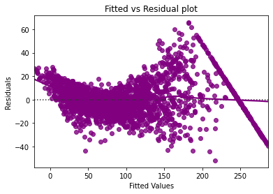

```python
sns.residplot(
    data=df_pred, x="Fitted Values", y="Residuals", color="purple", lowess=True
)
plt.xlabel("Fitted Values")
plt.ylabel("Residuals")
plt.title("Fitted vs Residual plot")
plt.show()
```

### TEST FOR NORMALITY

**Why the test?**

- Error terms, or residuals, should be normally distributed. If the error terms are not normally distributed, confidence intervals of the coefficient estimates may become too wide or narrow. Once confidence interval becomes unstable, it leads to difficulty in estimating coefficients based on minimization of least squares. Non-normality suggests that there are a few unusual data points that must be studied closely to make a better model.

**How to check normality?**

- The shape of the histogram of residuals can give an initial idea about the normality.
- It can also be checked via a Q-Q plot of residuals. If the residuals follow a normal distribution, they will make a straight line plot, otherwise not.
- Other tests to check for normality includes the Shapiro-Wilk test.
  - Null hypothesis: Residuals are normally distributed
  - Alternate hypothesis: Residuals are not normally distributed

**How to fix if this assumption is not followed?**

- We can apply transformations like log, exponential, arcsinh, etc. as per our data.

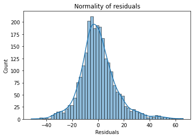

```python
sns.histplot(data=df_pred, x="Residuals", kde=True)
plt.title("Normality of residuals")
plt.show()
```

- The histogram of residuals does have a bell shape.
- checking the Q-Q plot.

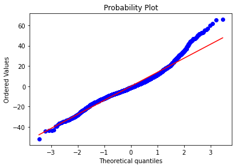

```python
import pylab
import scipy.stats as stats

stats.probplot(df_pred["Residuals"], dist="norm", plot=pylab)
plt.show()
```

- The residuals more or less follow a straight line except for the top.
- checking the results of the Shapiro-Wilk test.

```python
stats.shapiro(df_pred["Residuals"])
```

```
ShapiroResult(statistic=0.9625498652458191, pvalue=6.148109245242199e-25)
```

- Since p-value < 0.05, the residuals are not normal as per the Shapiro-Wilk test.
- Strictly speaking, the residuals are not normal.
- However, as an approximation, we can accept this distribution as close to being normal.
- **So, the assumption is satisfied.**

### TEST FOR HOMOSCEDASTICITY

- **Homoscedascity**: If the variance of the residuals is symmetrically distributed across the regression line, then the data is said to be homoscedastic.
- **Heteroscedascity**: If the variance is unequal for the residuals across the regression line, then the data is said to be heteroscedastic.

**Why the test?**

- The presence of non-constant variance in the error terms results in heteroscedasticity. Generally, non-constant variance arises in presence of outliers.

**How to check for homoscedasticity?**

- The residual vs fitted values plot can be looked at to check for homoscedasticity. In the case of heteroscedasticity, the residuals can form an arrow shape or any other non-symmetrical shape.
- The goldfeldquandt test can also be used. If we get a p-value > 0.05 we can say that the residuals are homoscedastic. Otherwise, they are heteroscedastic.
  - Null hypothesis: Residuals are homoscedastic
  - Alternate hypothesis: Residuals have heteroscedasticity

**How to fix if this assumption is not followed?**

- Heteroscedasticity can be fixed by adding other important features or making transformations.

```python
import statsmodels.stats.api as sms
from statsmodels.compat import lzip

name = ["F statistic", "p-value"]
test = sms.het_goldfeldquandt(df_pred["Residuals"], x_train3)
lzip(name, test)
```

```
[('F statistic', 1.0424575630713462), ('p-value', 0.23250737524465778)]
```

**Since p-value > 0.05, we can say that the residuals are homoscedastic. So, this assumption is satisfied.**

```python
# predictions on the test set
pred = olsmod2.predict(x_test3)

df_pred_test = pd.DataFrame({"Actual": y_test, "Predicted": pred})
df_pred_test.sample(10, random_state=1)
```

|  | Actual | Predicted |
| --- | --- | --- |
| 2098 | 30.5200 | 22.370992 |
| 278 | 195.6700 | 189.401958 |
| 26 | 247.1925 | 223.836285 |
| 2910 | 89.9700 | 90.578045 |
| 2631 | 69.2000 | 67.542633 |
| 1582 | 89.5800 | 110.384302 |
| 2110 | 247.1925 | 263.014087 |
| 3160 | 65.3400 | 64.634189 |
| 2817 | 115.7700 | 106.258837 |
| 549 | 39.2900 | 47.393840 |

- We can observe here that our model has returned pretty good prediction results, and the actual and predicted values are comparable.
- We can also visualize comparison result as a bar graph.
- Since data is large, we will be using 25 records for visualization.

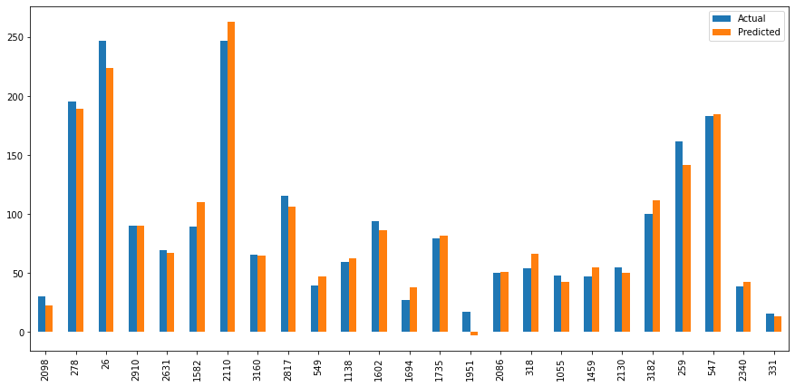

```python
df1 = df_pred_test.sample(25, random_state=1)
df1.plot(kind="bar", figsize=(15, 7))
plt.show()
```

```python
# checking model performance on train set (seen 70% data)
print("Training Performance\n")
olsmod2_train_perf = model_performance_regression(olsmod2, x_train3, y_train)
olsmod2_train_perf
```

```
Training Performance
```

|  | RMSE | MAE | R-squared | Adj. R-squared | MAPE |
| --- | --- | --- | --- | --- | --- |
| 0 | 14.054065 | 10.286428 | 0.954532 | 0.954276 | 18.571089 |

```python
# checking model performance on test set (seen 30% data)
print("Test Performance\n")
olsmod2_test_perf = model_performance_regression(olsmod2, x_test3, y_test)
olsmod2_test_perf
```

```
Test Performance
```

|  | RMSE | MAE | R-squared | Adj. R-squared | MAPE |
| --- | --- | --- | --- | --- | --- |
| 0 | 13.736034 | 10.124683 | 0.9575 | 0.956937 | 16.2796 |

**comparing the initial model created with sklearn and the final statsmodels model.**

```python
# training performance comparison

models_train_comp_df = pd.concat(
    [linearregression_train_perf.T, olsmod2_train_perf.T],
    axis=1,
)

models_train_comp_df.columns = [
    "Linear Regression sklearn",
    "Linear Regression statsmodels",
]

print("Training performance comparison:")
models_train_comp_df
```

```
Training performance comparison:
```

|  | Linear Regression sklearn | Linear Regression statsmodels |
| --- | --- | --- |
| RMSE | 13.988714 | 14.054065 |
| MAE | 10.251215 | 10.286428 |
| R-squared | 0.954954 | 0.954532 |
| Adj. R-squared | 0.954127 | 0.954276 |
| MAPE | 18.481330 | 18.571089 |

```python
# test performance comparison

models_test_comp_df = pd.concat(
    [linearregression_test_perf.T, olsmod2_test_perf.T],
    axis=1,
)

models_test_comp_df.columns = [
    "Linear Regression sklearn",
    "Linear Regression statsmodels",
]

print("Test performance comparison:")
models_test_comp_df
```

```
Test performance comparison:
```

|  | Linear Regression sklearn | Linear Regression statsmodels |
| --- | --- | --- |
| RMSE | 13.730895 | 13.736034 |
| MAE | 10.146914 | 10.124683 |
| R-squared | 0.957532 | 0.957500 |
| Adj. R-squared | 0.955669 | 0.956937 |
| MAPE | 16.308935 | 16.279600 |

- The performance of the two models is close to each other.
- Recreating the final statsmodels model adn printing its summary to gain insights.

```python
olsmodel_final = sm.OLS(y_train, x_train3).fit()
print(olsmodel_final.summary())
```

```
                            OLS Regression Results
==============================================================================
Dep. Variable:             used_price   R-squared:                       0.955
Model:                            OLS   Adj. R-squared:                  0.954
Method:                 Least Squares   F-statistic:                     4013.
Date:                Sun, 24 Oct 2021   Prob (F-statistic):               0.00
Time:                        09:24:11   Log-Likelihood:                -10151.
No. Observations:                2499   AIC:                         2.033e+04
Df Residuals:                    2485   BIC:                         2.041e+04
Df Model:                          13
Covariance Type:            nonrobust
======================================================================================
                         coef    std err          t      P>|t|      [0.025      0.975]
--------------------------------------------------------------------------------------
screen_size            0.2227      0.082      2.710      0.007       0.062       0.384
main_camera_mp        -0.2357      0.083     -2.853      0.004      -0.398      -0.074
selfie_camera_mp       0.7591      0.089      8.542      0.000       0.585       0.933
int_memory             0.0822      0.010      8.308      0.000       0.063       0.102
ram                   14.8855      0.464     32.051      0.000      13.975      15.796
days_used             -0.0839      0.002    -55.817      0.000      -0.087      -0.081
new_price              0.3868      0.003    134.476      0.000       0.381       0.392
brand_name_Apple       7.2809      2.371      3.070      0.002       2.631      11.931
brand_name_Gionee     -5.4180      2.312     -2.344      0.019      -9.951      -0.885
brand_name_Google     11.2336      4.117      2.729      0.006       3.161      19.306
brand_name_Infinix   -15.2852      5.798     -2.636      0.008     -26.655      -3.916
brand_name_Nokia      -8.6242      1.565     -5.510      0.000     -11.693      -5.555
brand_name_OnePlus   -16.5826      3.515     -4.717      0.000     -23.476      -9.689
4g_yes                -3.0047      0.798     -3.765      0.000      -4.570      -1.440
==============================================================================
Omnibus:                      287.462   Durbin-Watson:                   1.969
Prob(Omnibus):                  0.000   Jarque-Bera (JB):              643.399
Skew:                           0.688   Prob(JB):                    1.94e-140
Kurtosis:                       5.071   Cond. No.                     1.54e+04
==============================================================================

Notes:
[1] Standard Errors assume that the covariance matrix of the errors is correctly specified.
[2] The condition number is large, 1.54e+04. This might indicate that there are
strong multicollinearity or other numerical problems.
```

## Final Model Summary

1. Brand names suchs as Gionee, Infinix, Nokia and OnePlus come out to be very significant, as expected. As these two increase, the used_price decreases, as is visible in the negative coefficient sign. Since these brands for the cellphones are probably not customer's favorites.
1. If the main camera mp increases the used price decreases which is very interesting as it seems that the selfie camera mp has a better correlation than the negative correlation with used prices for the main camera mp.
2. Well Known brands such as Apple and Google increase so does the used prices.
3. Interesting to see that 4g has the negative correlation, assumption that the addition of 5g customer's do not want to buy the outdated 4g and would rather prefer 5g, which is more expensive.
4. The ram shows a very high correlation, so the higher the ram the higher the used price of the phone.

## Actionable Insights and Recommendations

-

- As a business it would be important to utilize first the well known brands as the value of those phones tend to increase based on the brands such as Apple or Google.
- It would be very profitable to attain phones that have higher ram than others as those used prices then to increase as the ram increases.
- In the world of social media where everyone is taking selfies, the social trends make it important to utilize the higher megapixels of used phones as they are more valuable than the less megapixels selfie cameras.